# Computational Document

체질량지수(BMI) - R마크다운(`.rmd`)

이광춘 (KPMG)

2019-10-26

# 1 비즈니스 설명

[캐글, “500 Person Gender-Height-Weight-Body Mass Index - Height and Weight random generated, Body Mass Index Calculated”](https://www.kaggle.com/yersever/500-person-gender-height-weight-bodymassindex)에서 데이터를 바탕으로 고객에게 체중과 키 정보만 제공하면 체질량 지수(Body Mass Index , BMI)를 예측하는 모형을 개발하여 고객이 궁금해하는 서비스를 개발하고자 한다.

> **체질량 지수(體質量指數, Body Mass Index, BMI)**는 인간의 비만도를 나타내는 지수로, 체중과 키의 관계로 계산된다. 키가 `t` 미터, 체중이 `w` 킬로그램일 때, BMI는 다음이 수식으로 표현된다. (키의 단위가 센티미터가 아닌 미터임에 유의해야 한다.)

> $$BMI = \frac{w}{t^2}$$

체질량지수 (BMI지수)로 과체중 혹은 비만을 판정하는 한국 사례 [^1]

| 구분 | BMI 지수 |
| --- | --- |
| 고도 비만 | 40 이상 |
| 중등도 비만 (2단계 비만) | 35 - 39.9 |
| 경도 비만 (1단계 비만) | 30 - 34.9 |
| 과체중 | 25 - 29.9 |
| 정상 | 18.5 - 24.9 |
| 저체중 | 18.5 미만 |

# 2 데이터

[캐글, “500 Person Gender-Height-Weight-Body Mass Index - Height and Weight random generated, Body Mass Index Calculated”](https://www.kaggle.com/yersever/500-person-gender-height-weight-bodymassindex)에서 데이터를 바탕으로 고객에게 체중과 키 및 라벨 데이터 **index**가 준비되어 있어 키와 몸무게를 통해 BMI 예측한다.

## 2.1 데이터 사전

- Gender : Male / Female
- Height : Number (cm)
- Weight : Number (Kg)
- Index :
  - 0 : Extremely Weak
  - 1 : Weak
  - 2 : Normal
  - 3 : Overweight
  - 4 : Obesity
  - 5 : Extreme Obesity

## 2.2 데이터 가져오기

캐글에서 내려받은 원본 데이터를 살펴본다.

```r
library(tidyverse)

bmi_dat <- read_csv("https://raw.githubusercontent.com/statkclee/author_carpentry_kr/gh-pages/data/500_Person_Gender_Height_Weight_Index.csv")

glimpse(bmi_dat)
```

```
Observations: 500
Variables: 4
$ Gender <chr> "Male", "Male", "Female", "Female", "Male", "Male", "Male…
$ Height <dbl> 174, 189, 185, 195, 149, 189, 147, 154, 174, 169, 195, 15…
$ Weight <dbl> 96, 87, 110, 104, 61, 104, 92, 111, 90, 103, 81, 80, 101,…
$ Index  <dbl> 4, 2, 4, 3, 3, 3, 5, 5, 3, 4, 2, 4, 3, 2, 2, 5, 5, 5, 5, …
```

```r
bmi_dat %>%
  DT::datatable()
```

|  | Gender | Height | Weight | Index |
| --- | --- | --- | --- | --- |
| 1 | Male | 174 | 96 | 4 |
| 2 | Male | 189 | 87 | 2 |
| 3 | Female | 185 | 110 | 4 |
| 4 | Female | 195 | 104 | 3 |
| 5 | Male | 149 | 61 | 3 |
| 6 | Male | 189 | 104 | 3 |
| 7 | Male | 147 | 92 | 5 |
| 8 | Male | 154 | 111 | 5 |
| 9 | Male | 174 | 90 | 3 |
| 10 | Female | 169 | 103 | 4 |

[output cut: 490 more lines]

# 3 탐색적 데이터 분석

## 3.1 요약 통계

```r
bmi_df <- bmi_dat %>%
  mutate(Index = factor(Index, levels = c(0,1,2,3,4,5), labels = c("극저체중", "저체중", "정상", "과체중", "비만", "고도비만")),
         Gender = factor(Gender, levels = c("Male", "Female")))

bmi_df %>%
  group_by(Index) %>%
  summarise(평균키 = mean(Height),
            평균체중 = mean(Weight))
```

```
# A tibble: 6 x 3
  Index    평균키 평균체중
  <fct>     <dbl>    <dbl>
1 극저체중   188.     51.7
2 저체중     185.     59.4
3 정상       174.     69.1
4 과체중     176.     86.9
5 비만       174.    108.
6 고도비만   161.    133.
```

## 3.2 시각화

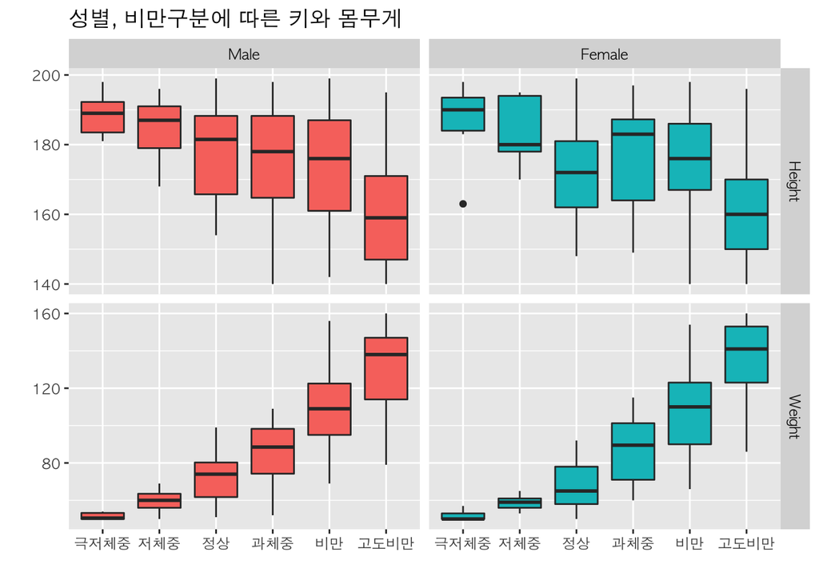

```r
bmi_df %>%
  gather(키체중, 값, -Gender, -Index) %>%
  ggplot(aes(x=Index, y= 값, fill=Gender)) +
    geom_boxplot(show.legend = FALSE) +
    facet_grid(키체중 ~ Gender,  scales="free") +
    labs(x="", y="",
         title="성별, 비만구분에 따른 키와 몸무게")
```

# 4 예측모형 - BMI 예측

$$\text{BMI 그룹} = f(\text{성별}, \text{키}, \text{몸무게}) + \epsilon$$
BMI 그룹: “극저체중”, “저체중”, “정상”, “과체중”, “비만”, “고도비만”

```r
# 0. 환경설정 ------
library(caret)
library(doSNOW)

set.seed(777)

# 1. 데이터 ------
# bmi_df

# 2. 데이터 전처리 ------

# 3. 예측모형 ------
## 3.1. 병렬처리 환경설정
num_cores <- parallel:::detectCores()
start_time <- Sys.time()

cl <- makeCluster(num_cores, type = "SOCK")
registerDoSNOW(cl)

## 3.2. 훈련 vs 검증/시험
train_test_index <- createDataPartition(bmi_df$Index, p = 0.7, list = FALSE)

train <- bmi_df[train_test_index, ]
test <- bmi_df[-train_test_index, ]

## 3.3. 모형 개발/검증 데이터셋 준비 ------
cv_folds <- createMultiFolds(train$Index, k = 10, times = 5)
cv_ctrl <- trainControl(method = "cv", number = 10,
                        index = cv_folds,
                        verboseIter = TRUE)
## 3.2. 예측모형 적용
### ranger
gc_ranger_model <- train(Index ~., train,
                  method = "ranger",
                  tuneLength = 7,
                  trControl = cv_ctrl)
# 4. 모형 비교평가-----
gc_pred_class <- predict(gc_ranger_model, newdata = test, type="raw")
## 혼동행렬 -----
bmi_conf <- confusionMatrix(gc_pred_class, test$Index)

bmi_conf$table
```

```
          Reference
Prediction 극저체중 저체중 정상 과체중 비만 고도비만
  극저체중        3      0    0      0    0        0
  저체중          0      4    1      0    0        0
  정상            0      2   15      1    0        0
  과체중          0      0    2     16    0        0
  비만            0      0    2      3   38        4
  고도비만        0      0    0      0    1       55
```

```r
cat("정확도: ", scales::percent(bmi_conf$overall[["Accuracy"]]))
```

```
정확도:  89.1%
```

```r
stopCluster(cl)
```

# 5 BMI 예측

```r
bmi_test_dat <- tribble(
   ~"Gender", ~"Height", ~"Weight",
   "Male", 149, 61,
   "Female",  172, 67
)

predict(gc_ranger_model, newdata = bmi_test_dat, type="raw")
```

```
[1] 과체중 정상
Levels: 극저체중 저체중 정상 과체중 비만 고도비만
```

[^1]: [위키백과, “체질량 지수” (2019-04-22 접근함)](https://ko.wikipedia.org/wiki/%EC%B2%B4%EC%A7%88%EB%9F%89_%EC%A7%80%EC%88%98)